Edisi contoh: bagian depan buku, Bab 1–3, dan Daftar Kata. Dapatkan buku lengkap

# Satu Napas

Buku Pertama dari Tiga

Eramuse

2026

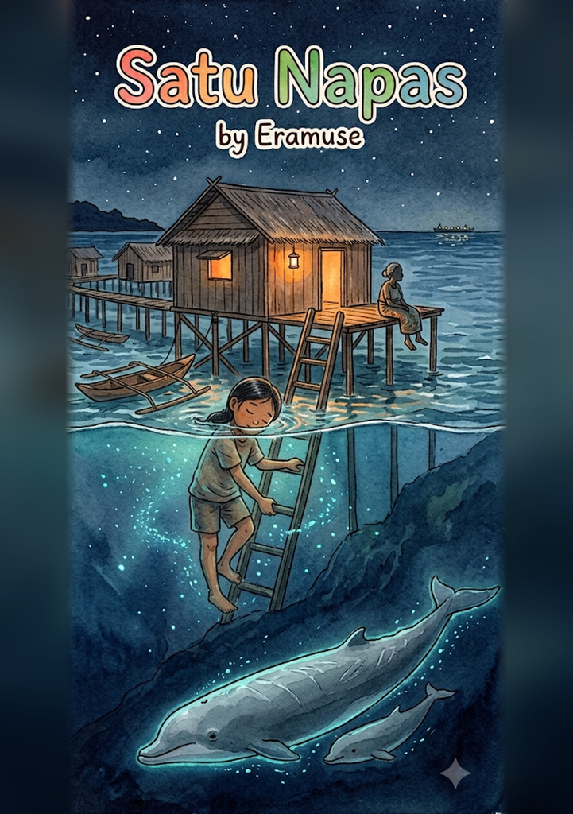

# Satu Napas

*Buku Pertama dari Tiga*

Eramuse

*Untuk segala umur — dibacakan untuk anak 8 tahun ke atas, dan bisa dibaca sendiri oleh anak 10 tahun ke atas*

Eramuse House

# Hak Cipta

**Satu Napas**  
Buku Pertama dari Tiga

Penulis: Eramuse  
Penerbit: Eramuse House  
Cetakan pertama, 2026

Hak cipta © 2026 Eramuse

Hak cipta dilindungi undang-undang. Dilarang memperbanyak, menyalin, atau menyebarluaskan sebagian atau seluruh isi buku ini dalam bentuk apa pun tanpa izin tertulis dari pemegang hak cipta, kecuali untuk kutipan singkat dalam ulasan atau keperluan pendidikan dengan menyebutkan sumbernya.

Guru dan sekolah boleh memperbanyak halaman **Yang Nyata di Bab Ini**, **Untuk dipikirkan**, puisi pembuka, dan pantun penutup untuk keperluan mengajar di kelas, tanpa perlu meminta izin.

**Pernyataan fiksi.** Buku ini karya fiksi. Kampung Pari dan seluruh tokoh di dalamnya adalah rekaan. Tidak ada tokoh dalam buku ini yang dimaksudkan menggambarkan orang sungguhan, baik yang masih hidup maupun yang sudah meninggal. Kemiripan semacam itu, kalau ada, adalah kebetulan semata. Sebagian tempat, lembaga, dan penemuan ilmiah yang disebut di sini memang nyata, dan dijelaskan satu per satu di bagian belakang buku.

**Keaslian dan koreksi.** Cerita, tokoh, dan seluruh gagasan dalam buku ini disusun oleh penulis, dengan bantuan kecerdasan buatan sebagaimana dijelaskan di halaman berikutnya. Kalau ada keterangan yang keliru, atau ada sumber yang seharusnya kami sebut tetapi terlewat, tolong beri tahu kami. Akan kami perbaiki pada cetakan berikutnya.

ayomath.com · eramusehouse@gmail.com

# Tentang Buku Ini

Buku ini ditulis oleh manusia, dengan bantuan kecerdasan buatan (AI).

Idenya bukan dari mesin. Kampung di atas laut, Pari, Udin, Mbo, si pengetuk, dan seluruh jalan ceritanya dipilih dan diputuskan oleh manusia. Yang dibantu mesin adalah menyusun kalimat, memeriksa angka dan fakta ilmiah, dan menemukan bagian yang keliru. Dulu pekerjaan itu dikerjakan penyunting. Sekarang dikerjakan bersama.

Rasanya pantas disebutkan. Sebab di dalam buku ini ada komputer yang sangat yakin, padahal salah. Karena itu, semua yang dibantu mesin kami periksa ulang. Dan kami tetap bertanya kepada manusia: kepada guru, kepada ilmuwan, dan kepada orang-orang yang tinggal di dekat laut.

Ilmu pengetahuan terus berubah. Kalau suatu hari kamu menemukan fakta yang lebih baru, itu artinya kamu sudah mulai berpikir seperti ilmuwan.

# Sebelum Membaca: Tentang Menyelam

Pari dan teman-temannya tumbuh di atas laut. Mereka belajar menyelam sejak kecil, dengan orang tua yang selalu mengawasi. Tapi menyelam bisa sangat berbahaya, bahkan bagi penyelam yang hebat.

Karena itu, tolong ingat hal-hal ini:

- **Jangan pernah menyelam sendirian.** Satu turun, satu jaga. Selalu.
- **Anak-anak hanya boleh berenang dan menyelam dengan pengawasan orang dewasa** yang pandai berenang dan kenal tempat itu.
- **Jangan berlomba menahan napas di dalam air.** Orang bisa pingsan tanpa merasakan tanda apa pun. Pengukuran menahan napas di buku ini dilakukan oleh ahli, dengan pengawasan ketat.
- **Jangan menarik napas cepat berulang-ulang sebelum menyelam.** Cara itu membuat tanda bahaya dari tubuh datang terlambat.
- **Kalau telinga sakit, naik.** Jangan dipaksa.
- **Menyelam dengan kompresor atau tabung udara hanya untuk orang yang terlatih dan bersertifikat.** Kompresor udara biasa sangat berbahaya untuk bernapas di dalam air.
- **Pakai alas kaki di karang.** Karang tajam, dan bulu babi berduri.
- **Percobaan baskom air dingin** di Bab 3 harus ditemani orang dewasa. Kalau kamu punya masalah jantung atau pernapasan, tanyakan dulu kepada dokter.
- **Kalau menemukan paus atau lumba-lumba terdampar**, baca catatan di akhir buku, dan segera hubungi petugas.

Kata-kata yang mungkin baru buat kamu ada di Daftar Kata, di bagian belakang buku.

Laut itu indah, tapi besar sekali. Menyelamlah dengan hormat, dan selalu pulang dengan selamat.

# Untuk Orang Tua dan Guru: Membaca Bersama

Buku ini bisa **dibacakan untuk anak 8 tahun ke atas**, dan **dibaca sendiri oleh anak 10 tahun ke atas**. Kalimatnya pendek. Yang membuatnya menantang adalah ceritanya yang panjang dan ilmunya yang banyak. Karena itu, buku ini paling seru kalau dibaca bersama.

- **Satu bab sekali duduk.** Setiap bab kira-kira sepuluh menit kalau dibaca keras.
- **Berhenti di bagian yang seru.** Tanyakan: *“Menurutmu, apa yang akan terjadi?”* Tidak apa-apa kalau tebakannya salah. Pari juga sering salah.
- **Baca “Yang Nyata di Bab Ini” bersama.** Tidak perlu dihafal. Cukup dibicarakan.
- **“Untuk dipikirkan” tidak punya jawaban benar atau salah.** Pertanyaan itu untuk diobrolkan, bukan untuk dinilai.
- **Kata yang sulit** ada di Daftar Kata, di bagian belakang buku.
- **Coba percobaannya bersama**, dengan aman. Menghitung detak jantung sebelum dan sesudah wajah masuk baskom air dingin (Bab 3). Menempelkan telinga ke meja sambil mengetuk ujungnya pelan-pelan (Bab 14).
- **Ajak anak mendengarkan.** Duduk diam satu menit, mata terpejam, lalu hitung berapa bunyi yang terdengar. Siapa yang mendengar paling banyak?
- **Baca halaman “Tentang Menyelam” bersama anak** sebelum mulai. Laut itu indah, tapi harus dihormati.

# Satu Napas

Rumahku berdiri di atas laut,  
bertiang kayu, beratap bintang.  
Setiap senja di bawah lantai,  
ombak berbisik memanggil pulang.

Jauh di dalam, di biru tua,  
ada yang mengetuk: *tik, tik, tik*.  
Tidak semua telinga mendengarnya,  
hanya yang mau diam sedetik.

Satu turun, satu menjaga,  
satu napas, jangan lebih.  
Laut tidak butuh pahlawan,  
laut butuh yang kembali.

Nanti bila telingaku pergi,  
siapa yang akan bercerita?  
Mungkin kamu, yang membaca ini,  
yang mau diam, lalu bertanya.

# Bagian 1 — Kapal Datang

## Bab 1 — Perekam yang Jatuh

*Wakatobi, Sulawesi Tenggara. Tahun 2031.*

“Satu… dua… *tiga!*”

Pari dan Udin melompat dari perahu kecil bersamaan. Air hijau yang bening menelan mereka.

Udin sahabat Pari. Rumahnya hanya tiga rumah dari rumah Pari. Mereka sudah berenang bersama sejak belum bisa berjalan.

Lombanya sederhana. Siapa yang pertama menyentuh pasir di dasar lalu kembali ke atas, dia menang. Yang kalah harus mendayung pulang.

Udin menendang sekuat tenaga. Gelembung meledak di sekelilingnya seperti air mendidih. Pari tidak. Pari meluncur rendah dan pelan, seperti ikan pari yang pipih itu. Karena itulah anak-anak kampung memanggilnya Pari. Nama aslinya Sarina.

Tangannya menyentuh pasir lebih dulu. Ia menggenggam segenggam, lalu naik.

“Curang!” teriak Udin begitu kepalanya muncul.

Pari membuka genggamannya. Pasir putih mengalir di sela jarinya. “Kamu kebanyakan gelembung.”

“Gelembung bukan curang!”

“Gelembung itu napas yang dibuang.”

Udin mengomel sambil mengambil dayung. Kalah tetap kalah.

Sebelum naik ke perahu, Pari memasukkan kepalanya sekali lagi ke air. Ia selalu begitu. Mendengarkan.

Derik udang, seperti minyak panas di wajan. Bunyi karang yang ia kenal sejak kecil.

Tapi akhir-akhir ini deriknya lebih pelan. Dulu seperti hujan deras di atap seng. Sekarang seperti gerimis. Pari tidak tahu kenapa. Ia juga tidak pernah bilang kepada siapa-siapa.

Dari perahu itu, kampung mereka seperti hutan tiang. Rumah-rumah kayu berdiri di atas laut. Jembatan papan menyambung satu rumah dengan rumah lain. Orang-orang di sana menyebut diri mereka orang Sama. Orang dari darat menyebut mereka orang Bajo. Hampir semua anaknya bisa menyelam sebelum bisa membaca.

Di ujung teras salah satu rumah, seorang nenek duduk memandang laut. Itu Mbo, nenek Pari.

Jauh di luar karang ada kapal putih. Sudah seminggu kapal itu di sana. Kata Pak Ramli, isinya orang pintar dari Jakarta dan orang asing.

Sore itu sebuah perahu karet abu-abu dari kapal putih berhenti di tepi karang. Jaraknya hanya sepelempar batu dari perahu kecil Pari dan Udin. Di atasnya ada tiga orang. Seorang perempuan bertopi lebar. Seorang laki-laki jangkung berkacamata. Dan seorang pemuda yang sedang menurunkan benda kuning dengan tali.

Lalu simpul talinya lepas.

*Plung.*

Perempuan bertopi itu berteriak. Benda kuning itu tenggelam, berputar pelan menyusuri dinding karang.

Udin sudah mendayung sebelum disuruh. Dalam beberapa kayuhan, perahu kecil mereka sudah bersebelahan dengan perahu karet itu. Begitu dekat sampai Pari bisa mendengar perempuan bertopi itu terengah-engah.

Pari melongok ke dalam air. Di bawah sana ada tonjolan batu seperti rak. Benda kuning itu tersangkut di situ, bergoyang kena arus. Di bawah rak itu hanya ada biru tua. Makin dalam makin gelap. Lalu hitam.

“Aduh,” kata perempuan bertopi. “Kalau jatuh lagi, hilang sudah. Di bawah situ dalamnya ribuan meter.”

“Penyelam kita masih di kapal,” kata laki-laki berkacamata. “Setengah jam lagi baru siap.”

“Arusnya tidak akan menunggu.”

Pari mengukur dengan mata, seperti yang diajarkan Bapak. Warna airnya. Kecilnya karang di sekitar benda itu.

“Dua belas meter,” katanya.

Ketiga orang itu menoleh. Seperti baru sadar ada dua anak di situ.

Pari menoleh ke Udin. “Kamu jaga.”

Udin langsung mengerti. Itu aturan Bapak Pari. Satu turun, satu jaga. Tidak pernah dua-duanya. Tidak pernah sendirian.

“Jangan!” kata perempuan bertopi. Lalu ia melihat wajah Pari, dan cepat-cepat melempar gulungan tali ke air. Di ujungnya ada pengait logam. “Jangan diangkat. Berat. Kaitkan saja, lalu tarik dua kali. Kami yang menarik.”

Pari menangkap pengait itu. Ia menarik napas.

Ia turun kepala lebih dulu. Dua tendangan, lalu tubuhnya tenggelam pelan menyusuri dinding karang.

Di lima meter, telinganya terasa ditekan. Seperti ada jari yang mendorong dari luar. Ia memencet hidung dan meniup pelan. *Plop.* Tekanannya hilang.

Di delapan meter, air lebih dingin. Warna karang memucat. Semuanya kebiruan. Telinganya ditekan lagi. *Plop.*

Lalu ia mendengarnya.

*Tik. Tik. Tik-tik-tik-tik.*

Si pengetuk.

Pari sudah mendengar bunyi itu sejak kecil. Setiap senja, dari anak tangga rumahnya. Tipis dan tinggi, seperti kuku diketuk ke kaca, jauh di tempat yang biru tua. Tidak pernah ia ceritakan kepada siapa pun. Untuk apa? Semua orang pasti dengar. Tidak ada yang bercerita tentang angin.

Tapi di sini bunyinya lebih jelas dari biasanya. Lebih dekat.

*Tik-tik-tik-tik-tik. Zzzt.*

Tangannya menyentuh batu. Ia mengaitkan pengait ke gagang benda kuning itu. *Klik.* Lalu ia menarik tali dua kali.

Sebentar saja ia menoleh ke bawah. Biru tua. Lalu hitam. Tidak ada dasar.

Dadanya mulai penuh. Ia menendang ke atas.

Air makin terang. Makin hangat. Di atas sana ada bayangan perahu, dan wajah Udin yang menempel di permukaan air tanpa berkedip.

Pari muncul. Udara masuk seperti air dingin ke tenggorokan. Di sebelahnya, benda kuning itu ikut naik ditarik tali. Benda itu berputar-putar seperti ikan yang tertangkap.

Perempuan bertopi itu mengangkat benda kuning ke perahu dengan dua tangan. Ia menekan tombol. Di layar kecilnya muncul angka.

“Dua belas koma empat meter,” bacanya pelan.

Laki-laki berkacamata menatap Pari. “Umurmu berapa?”

“Sebelas.”

Kedua orang dewasa itu saling pandang lama.

“Saya Wulan,” kata perempuan itu. Ia tersenyum. Hidungnya terkelupas terbakar matahari. “Ini alat perekam bunyi. Selama di bawah tadi, dia terus merekam. Semua yang ada di bawah sana, dia dengar.”

*Semua.* Berarti juga si pengetuk. Entah kenapa, Pari senang sekali.

“Rumahmu yang mana?” tanya laki-laki berkacamata. “Besok, boleh kami bicara dengan orang tuamu?”

Malamnya, waktu membersihkan ikan, Pari menemukan benang biru di perut seekor ikan kakap. Tipis, sepanjang kelingking. Ia menjentikkannya ke sela lantai. Benang itu jatuh ke laut tanpa bunyi.

Ia tidak memikirkannya. Kepalanya penuh hal lain.

Dua belas koma empat meter. Jurang yang tidak ada dasarnya. Si pengetuk, dekat sekali.

Dan besok, orang-orang dari kapal putih akan datang ke rumahnya.

**Yang Nyata di Bab Ini**

- Setiap turun sekitar sepuluh meter, tekanan air bertambah sebanyak tekanan seluruh udara di atas kepala kita. Di dua belas meter, tubuh Pari ditekan lebih dari dua kali lipat dibanding di permukaan.
- Penyelam menyamakan tekanan di telinga dengan memencet hidung lalu meniup pelan. Udara dari tenggorokan masuk ke telinga dan mendorong balik.
- Di beberapa tempat, Laut Banda dalamnya lebih dari tujuh kilometer. Gunung tertinggi di Indonesia pun akan tenggelam seluruhnya di sana.

**Untuk dipikirkan:** Udin juga pandai menyelam. Kenapa Pari menyuruhnya berjaga di atas?

## Bab 2 — Pari Si Penyelam

*Pari menyelamatkan alat perekam dari tepi jurang. Hari ini orang-orang kapal putih datang ke rumahnya.*

Mama bangun sebelum subuh dan menyapu rumah dua kali.

“Ma, mereka cuma mau bicara.”

“Orang dari kapal besar mau datang,” kata Mama. Ia menyapu bagian yang sudah bersih. “Masa lantainya kotor.”

Bapak menjahit jaring di sudut. Ia pura-pura tidak peduli, padahal sudah memakai kemeja Jumat. Kaki kanan Bapak kaku, dan ia berjalan sedikit pincang. Dulu ia penyelam. Sekarang ia memperbaiki jaring orang dan membantu Mama di pasar. Kak Rusdi duduk di pintu dengan rambut disisir basah. Udin datang paling pagi. Tidak ada yang mengundangnya. Katanya, ia saksi.

Hanya Mbo yang tidak berubah. Ia duduk di ujung teras seperti biasa.

Perahu karet abu-abu merapat ke tangga rumah. Bu Wulan naik lebih dulu. Di belakangnya, laki-laki berkacamata itu membungkuk supaya kepalanya tidak terantuk atap.

Ia berdiri di tengah ruangan. Lalu ia mengucapkan salam dalam bahasa Sama.

Seisi rumah terdiam.

Logatnya aneh. Tapi itu bahasa mereka. Ia terus bicara, dan di tengah kalimatnya ada satu kata yang membuat Kak Rusdi menutup mulut. Udin berguling di lantai sambil tertawa.

Laki-laki itu berhenti. “Salah, ya?”

“Bapak bilang terima kasih kepada ikan,” kata Pari.

Semua orang tertawa. Bahkan Mama. Laki-laki itu tertawa paling keras.

“Nama saya Rafael. Dari Universitas Filipina,” katanya. “Di sana juga ada orang Sama. Saya belajar bahasa dari mereka. Ternyata nama ikan di sana dan di sini beda.”

Mereka duduk di tikar. Dalam lima menit, kaki Bu Wulan sudah kesemutan. Dr. Rafael duduk bersila seperti orang kampung.

“Saya meneliti bunyi di laut,” kata Bu Wulan. “Kami menaruh alat perekam di banyak tempat. Kadang talinya putus. Kadang arusnya kuat.” Ia melirik Pari. “Kami butuh orang yang kenal karang di sini. Yang bisa menyelam kalau perlu. Dibayar, tentu.”

Mama langsung duduk tegak. “Anak saya baru sebelas tahun.” Ia menatap Pari tajam. “Dan kemarin dia turun dua belas meter. Di tepi jurang. Tidak ada orang dewasa di dalam air. Cuma Udin yang jaga.”

Pari menunduk. Udin, di pojok, pura-pura sibuk dengan kakinya.

“Ibu benar,” kata Bu Wulan. Wajahnya serius. “Itu salah kami juga. Kami seharusnya melarang, bukan melempar tali. Kami terlalu takut kehilangan alat.” Ia menatap Pari. “Alat bisa dibeli lagi. Kamu tidak.”

Ruangan jadi sunyi.

“Mulai sekarang,” kata Bu Wulan, “tidak pernah seperti kemarin. Selalu ada orang dewasa di dalam air. Selalu dengan tali. Dan anak-anak tidak boleh lebih dari lima meter.”

Mama memandanginya lama. Lalu mengangguk sekali. Seperti Mbo.

Lalu Dr. Rafael. “Saya meneliti tubuh. Bagaimana orang Sama bisa menyelam begitu lama. Kami mau mengukur banyak orang di kampung ini. Jantung, napas, telinga.” Ia menatap Pari. “Kemarin kamu turun dua belas meter. Saya mau tahu bagaimana tubuhmu melakukannya.”

Pari merasa wajahnya panas. Belum pernah ada orang dewasa yang ingin tahu hal seperti itu tentang dirinya.

Bu Wulan mencondongkan badan. “Satu hal lagi. Kemarin kamu bilang dua belas meter, sebelum menyelam. Hampir tepat. Bagaimana kamu tahu?”

Pari berpikir. Tidak ada yang pernah menanyakan itu. Ia tahu saja.

“Dari warnanya,” katanya akhirnya. “Makin dalam, makin biru. Karang merah jadi cokelat, lalu jadi hitam. Di dua belas meter, bunga karang yang merah kelihatan hitam.”

Bu Wulan menatapnya. Lalu menatap Dr. Rafael.

“Warna merah hilang paling dulu di dalam air,” kata Bu Wulan pelan. “Ilmuwan butuh alat untuk mengukurnya. Kamu pakai mata.”

“Bapak yang ajari,” kata Pari.

Di sudut ruangan, Bapak pura-pura sibuk dengan jaringnya. Tapi jarumnya berhenti bergerak.

Surat izinnya enam halaman. Mama membaca semuanya, satu jam penuh, dengan kacamata yang biasa dipakai menghitung uang. Udin sampai tertidur.

Akhirnya Mama menutup surat itu. “Boleh berhenti kapan saja. Dibayar untuk hari yang sudah diikuti. Adil.” Lalu ia tanda tangan.

Pari juga dapat kertas sendiri, satu halaman, penuh gambar. Di bawahnya tertulis tebal: *Kamu boleh bilang tidak.* Pari tidak bilang tidak. Ia menulis nama aslinya pelan-pelan: *Sarina.*

Dr. Rafael menempelkan stiker di kartunya. *P-27.*

Udin terbangun. “Aku juga!” Ia dapat *P-28* dan langsung memamerkannya seperti lencana polisi.

Sebelum pulang, Dr. Rafael berhenti di ujung teras. Ia menyapa Mbo dalam bahasa Sama, pelan dan hormat. Kali ini tidak ada ikan yang disebut. Ia bertanya apakah Mbo mau ikut diukur.

Mbo memandanginya lama. Dari sepatunya yang basah sampai kacamatanya yang berembun.

“Tidak,” kata Mbo.

Dr. Rafael mengangguk sopan.

“Mbo sudah diukur laut tujuh puluh tahun,” tambah Mbo. “Laut saja belum selesai. Masa kamu mau selesai dalam seminggu?”

Dr. Rafael tertawa. Mbo tidak. Tapi sudut bibirnya bergerak sedikit.

Waktu perahu karet mulai menjauh, Bu Wulan menoleh dan berteriak.

“Pari! Rekaman dari alat kemarin!”

“Kenapa?”

“Ada bunyi aneh! Tinggi sekali! Saya belum tahu itu apa!”

Perahu itu menjauh, meninggalkan garis putih di air.

Pari berdiri di ujung teras. Jantungnya berdebar. Bunyi aneh. Tinggi sekali.

Di sebelahnya, Udin menarik-narik lengannya. “Besok semua orang diukur. Kayak lomba!” Matanya bersinar. “Kali ini aku yang menang.”

**Yang Nyata di Bab Ini**

- Orang Sama tinggal di Indonesia, Malaysia, dan Filipina. Bahasanya mirip, tapi setiap daerah punya logat dan kata-katanya sendiri.
- Ilmu tentang cara tubuh bekerja disebut fisiologi. Ahli fisiologi mempelajari jantung, napas, dan cara tubuh menyesuaikan diri dengan tempat yang sulit.
- Peneliti laut sering meninggalkan alat perekam di dalam air selama berminggu-minggu. Alat itu merekam bunyi siang dan malam.

**Untuk dipikirkan:** Kalau kamu ilmuwan dan boleh mengukur satu hal tentang orang-orang di kampungmu, apa yang akan kamu ukur?

## Bab 3 — Hari Lomba

*Orang-orang kapal putih akan mengukur seluruh kampung. Kata Udin, kayak lomba.*

“Ini bukan lomba,” kata Dr. Rafael.

Ia mengatakannya tiga kali pagi itu. Terakhir waktu melihat Bu Hasnah menulis besar-besar di papan tulis yang digotong ke halaman sekolah:

**HARI LOMBA**

Di bawahnya ada tiga kolom. *BASKOM. LIMPA. NAPAS.*

“Bu Hasnah, ini penelitian.”

“Iya, Pak.” Bu Hasnah tidak menghapus apa-apa. “Tapi anak-anak lebih semangat kalau lomba.”

Dr. Rafael memandangi halaman. Empat puluh anak berbaris. Ibu-ibu membawa termos teh. Pak Ramli membawa kursi lipat. Seseorang membawa gendang.

“Baiklah,” kata Dr. Rafael. “Lomba.”

Anak-anak bersorak.

Pos pertama adalah baskom biru berisi air dan es dari kapal putih. Es! Anak-anak berebut memegangnya sampai jari mereka merah.

Setiap anak dijepit alat kecil di jarinya. Di layar muncul angka yang berkedip. Kata Dr. Rafael, itu detak jantung dalam satu menit.

Aturannya: tarik napas, lalu masukkan wajah ke air dingin.

Udin pertama. Sembilan puluh dua. Ia membenamkan wajahnya, dan dua detik kemudian mengangkatnya sambil menjerit.

“*Dingin!*”

Seisi halaman tertawa. Gendang dipukul.

Percobaan kedua, Udin bertahan. Semua mata menatap layar.

Sembilan puluh. Delapan puluh tujuh. Delapan puluh tiga. Delapan puluh.

Udin mengangkat kepala, basah dan terengah. “Jantungku pelan? Padahal aku kaget!”

Pari menatap layar itu lama. Kalau kaget, jantung harusnya cepat. Waktu Kak Rusdi mengagetkannya dari balik pintu, jantungnya berdebar-debar. Tapi air dingin di wajah justru membuat jantung pelan.

“Pak,” katanya. “Air dingin menyuruh jantung supaya hemat?”

Dr. Rafael memandanginya dengan alis terangkat. “Kamu baru saja menjelaskan sesuatu yang saya pelajari bertahun-tahun.”

Ia menggambar ikan paus di papan tulis. Gambarnya jelek sekali.

“Kayak terong,” kata Udin.

“Paus yang mirip terong,” kata Dr. Rafael. “Kalau paus menyelam, jantungnya juga melambat. Anjing laut juga. Kalian juga. Tubuh tahu kita masuk air. Oksigen harus dihemat. Darah dikumpulkan untuk otak dan jantung.”

Lalu giliran Pari. Delapan puluh delapan. Ia membenamkan wajahnya pelan. Ia membiarkan dinginnya masuk seperti di dasar karang.

*Dug. … Dug. … Dug.*

Enam puluh empat.

Bu Hasnah menulis angka itu di papan. Dr. Rafael menulis di tabletnya lama sekali.

Pos kedua ada di dalam kelas. Antreannya paling panjang.

Dr. Rafael mengoleskan cairan dingin ke perut setiap orang. Licin, seperti ingus raksasa. Setiap anak menjerit *iiih* dengan cara yang berbeda. Lalu ia menempelkan alat seperti sabun batangan. Di layar muncul gambar abu-abu, bergerak seperti awan badai.

“Mesin ini melihat pakai bunyi,” katanya. “Bunyinya masuk ke tubuh, menabrak sesuatu, lalu memantul. Seperti teriak di gua.”

Waktu giliran Pari, ia memasang telinga baik-baik. “Aku tidak dengar bunyinya.”

“Tidak ada yang bisa. Terlalu tinggi,” kata Dr. Rafael. “Bahkan untukmu.”

“Kenapa *bahkan* aku?”

Dr. Rafael berhenti, seperti orang yang salah bicara. “Maksudnya untuk anak-anak,” katanya cepat. “Berikutnya!”

Pos ini punya dua kejutan. Pertama, Pak Ramli tertidur waktu diukur. Dengkurannya terdengar sampai ke halaman. Kedua, Mama. Mama bukan penyelam, tapi limpanya juga besar.

“Sudah dari lahir,” kata Dr. Rafael. “Diturunkan dari nenek moyang.”

Mama menyentuh perutnya pelan. “Dari nenek,” katanya.

Pos ketiga di ujung dermaga. Setiap anak berbaring di permukaan air, wajah di dalam, memegang tali. Dr. Rafael berdiri di sebelahnya. Satu tangannya selalu di punggung si anak.

“Satu turun, satu jaga,” kata Udin bangga. “Aturan bapaknya Pari.”

“Bapaknya Pari orang pintar,” kata Dr. Rafael.

Udin bertahan satu menit sebelas detik. Anak-anak lain satu menit, atau kurang. Lalu Pari. Di tengah menahan napas, ia mendengar sesuatu yang aneh.

*Tik. Tik-tik.*

Si pengetuk. Di siang hari. Padahal biasanya ia hanya datang waktu senja. Bunyinya terputus-putus dan cepat, seperti orang yang tergesa-gesa.

Kenapa siang-siang? Pari hampir mengangkat kepala untuk bertanya. Lalu ia ingat, semua orang pasti juga dengar. Jadi ia diam saja.

Satu menit empat puluh. Lalu tangan Dr. Rafael menekan punggungnya dua kali, dan Pari naik, walaupun masih bisa lebih lama.

Sore itu Bu Hasnah membacakan hasilnya seperti mengumumkan juara tujuh belasan.

“Jantung paling pelan: Pari! Napas paling lama: Pari!”

Udin cemberut.

“Dan limpa…” Bu Hasnah memeriksa catatan. Alisnya naik. “Limpa paling besar di antara anak-anak: *Udin!*”

Halaman meledak. Udin melompat-lompat di dermaga. Ia tidak tahu apa artinya menang limpa. Tapi ia pemenang.

“Ini bukan lomba,” kata Dr. Rafael untuk keempat kalinya. Tidak ada yang mendengarkan. Ia sendiri tersenyum.

Mbo menonton dari ujung dermaga, di kursi yang dibawakan Kak Rusdi. Mbo tidak ikut diukur. Tapi Mbo mengomentari setiap anak seperti komentator sepak bola. Waktu Pari naik dari tali, Mbo hanya mengangguk sekali.

Bagi Pari, itu lebih berharga dari gendang seisi kampung.

Tapi waktu Bu Hasnah mengumumkan limpa Udin, Mbo mendengus keras.

“Punya Mbo pasti lebih besar,” katanya.

“Mbo kan tidak mau diukur,” kata Udin.

“Makanya,” kata Mbo, “tidak ada yang bisa membantah.”

Waktu orang-orang pulang, Dr. Rafael memanggil Pari.

“Besok, pos terakhir. Telinga.”

“Lomba juga?”

“Bukan lomba,” katanya. Lalu ia berhenti sebentar. “Tapi saya penasaran sekali siapa pemenangnya.”

**Yang Nyata di Bab Ini**

- Kalau wajah masuk air dingin sambil menahan napas, jantung melambat. Ini disebut refleks menyelam. Semua mamalia memilikinya, dari manusia sampai paus.
- Rasa ingin bernapas waktu menahan napas datang dari gas karbon dioksida yang menumpuk. Orang bisa kehilangan kesadaran tanpa tanda apa pun, jadi jangan pernah menyelam sendirian.
- Mesin ultrasonografi melihat ke dalam tubuh dengan bunyi yang terlalu tinggi untuk didengar. Tahun 2018, ilmuwan menemukan limpa orang Bajo lebih besar daripada limpa orang Saluan, suku yang tinggal di darat tidak jauh dari mereka. Bahkan orang Bajo yang tidak menyelam pun limpanya lebih besar.

**Untuk dipikirkan:** Coba refleks menyelam di rumah dengan baskom air dingin, ditemani orang dewasa. Hitung detak jantungmu sebelum dan sesudah. Apakah jantungmu melambat juga?

**Ini akhir dari tiga bab pertama.**

Cerita Pari masih panjang: masih ada 21 bab lagi.

Orang tua dan guru bisa mendapatkan buku lengkapnya (EPUB) di grup Eramuse House di Skeddo. Saat ini tanpa biaya.

# Daftar Kata

*Kata-kata yang mungkin baru buat kamu.*

### Bahasa Sama dan Bahasa Daerah

- **Sama / Bajo.** Orang Sama menyebut diri mereka *Sama*. Orang dari darat sering menyebut mereka *orang Bajo*. Mereka tinggal di laut dan pesisir Indonesia, Malaysia, dan Filipina.
- **Mbo.** Panggilan untuk nenek di keluarga Pari.
- **Katinting.** Perahu kecil bermesin tempel yang banyak dipakai di Sulawesi dan Maluku. Bunyi mesinnya juga disebut begitu.
- **Api laut.** Sebutan orang tua di kampung Pari untuk laut yang menyala di malam hari.
- **Beta, ose.** “Saya” dan “kamu” dalam bahasa Melayu Ambon, yang dipakai Kapten Hendrik.

### Kata Laut

- **Teritip.** Hewan kecil bercangkang keras yang menempel di kayu, batu, dan kapal.
- **Bulu babi.** Hewan laut berbentuk bulat dengan duri-duri tajam, sering bersembunyi di karang.
- **Plankton.** Makhluk hidup kecil sekali yang melayang di laut. Sebagian bisa menyala.
- **Paus paruh.** Kelompok paus bergigi dengan moncong seperti paruh. Mereka menyelam sangat dalam dan jarang terlihat.
- **Terdampar.** Keadaan paus atau hewan laut lain yang terjebak di pantai atau karang dan tidak bisa kembali ke air dalam.
- **Pasang purnama.** Pasang yang paling tinggi dan surut yang paling jauh, waktu bulan mati dan bulan purnama.
- **Migrasi vertikal.** Perjalanan hewan laut dalam yang naik ke dekat permukaan setiap malam, lalu turun lagi sebelum pagi.
- **Kanal suara.** Lapisan air di laut tempat bunyi bisa terperangkap dan berjalan sangat jauh.
- **Pemutihan karang.** Karang yang berubah putih karena air terlalu hangat.
- **Mikroplastik.** Potongan plastik yang lebih kecil dari lima milimeter.

### Kata Ilmu

- **Si pengetuk.** Nama yang Pari berikan untuk bunyi *tik, tik, tik* dari laut dalam.
- **Hidrofon.** Mikrofon yang bisa mendengar di dalam air.
- **Spektrogram.** Gambar bunyi. Menunjukkan tinggi rendah dan keras pelannya bunyi.
- **Audiogram.** Peta pendengaran seseorang.
- **Hertz.** Satuan untuk berapa kali bunyi bergetar setiap detik.
- **Fisiologi.** Ilmu tentang cara tubuh bekerja.
- **Limpa.** Bagian tubuh yang menyimpan darah merah.
- **Refleks menyelam.** Jantung melambat waktu wajah masuk air dingin sambil menahan napas.
- **Ultrasonografi.** Cara melihat ke dalam tubuh dengan bunyi yang sangat tinggi.
- **Karbon dioksida.** Gas buangan dari tubuh. Gas ini yang membuat kita ingin bernapas.
- **Penyakit dekompresi.** Penyakit penyelam yang naik terlalu cepat setelah menghirup udara bertekanan.
- **Infrasonik.** Bunyi yang terlalu rendah untuk didengar, tapi bisa terasa di tubuh.
- **Bioluminesensi.** Cahaya yang dibuat oleh makhluk hidup.
- **Glider laut.** Robot bawah air yang bergerak dengan mengubah beratnya sendiri.
- **Survei seismik.** Cara mencari gas dan minyak dengan mengirim bunyi kuat ke dasar laut.
- **DNA lingkungan.** Serpihan tubuh makhluk hidup di air atau tanah, yang bisa dibaca di laboratorium.
- **Rata-rata.** Angka yang mewakili sekelompok angka.
- **Pencilan.** Angka yang jauh sekali dari angka-angka lain.

### Nama Lembaga

- **BRIN.** Badan Riset dan Inovasi Nasional, lembaga penelitian milik pemerintah Indonesia. Bu Wulan bekerja di sini.
- **Universitas Filipina.** Universitas negeri terbesar di Filipina, dengan pusat penelitian laut yang terkenal. Dr. Rafael berasal dari sini.
- **KKP.** Kementerian Kelautan dan Perikanan, yang antara lain bertugas menangani paus dan lumba-lumba terdampar.
- **Whale Stranding Indonesia.** Jaringan relawan dan ahli yang mencatat kejadian paus dan lumba-lumba terdampar di Indonesia.
- **Taman Nasional Wakatobi.** Kawasan laut yang dilindungi di Sulawesi Tenggara, tempat cerita ini terjadi.